# Chapter 5 Nonlinear models

Many real-world relationships between variables are inherently nonlinear. Linear models often fall short in capturing such complex patterns. To address this, various nonlinear modeling techniques have been developed that can flexibly adapt to intricate data structures.

This chapter introduces several major classes of nonlinear models, including neural networks, multivariate adaptive regression splines (MARS), support vector machines (SVMs), and K-nearest neighbors (KNN). Each of these models captures nonlinearities in distinct ways: neural networks through layered nonlinear transformations, MARS through piecewise basis functions, SVMs through kernel mappings, and KNN through local averaging in feature space.

While many nonlinear techniques exist, tree-based methods such as decision trees, random forests, and gradient boosting machines will be explored separately in the next chapter, given their distinctive structure and interpretability. Together, these models form a powerful toolkit for analyzing complex data and improving predictive performance in settings where linear assumptions are insufficient.

# 5.1 Neural networks

A neural network (Bishop, 1995; Ripley, 1996; Goodfellow et al., 2016) is a computational model inspired by the structure and functioning of the human brain. It is designed to recognize patterns and model complex, nonlinear relationships between inputs and outputs. A neural network consists of interconnected processing units, called neurons, organized into layers. Each neuron transforms its inputs into an output signal, which is then passed to other neurons in subsequent layers. Through this layered processing, the network learns to approximate functions, make predictions, or classify data.

Neural networks have become central to modern machine learning due to their ability to automatically learn representations from data, making them effective for a wide range of applications such as image recognition, speech processing, natural language understanding, and predictive analytics.

## Structure of a Neural Network

1. **Neuron**: The basic building block of a neural network. Each neuron receives input from other neurons or from the input data, performs a computation, and produces an output. The output is typically determined by applying an activation function to the weighted sum of its inputs.
2. **Layers**: A neural network generally consists of three types of layers:
   - **Input Layer**: This layer receives the input data and forwards it to the next layer. Each neuron in the input layer corresponds to a feature or attribute of the input data.
   - **Hidden Layers**: Positioned between the input and output layers, these layers perform computations on the data. Each neuron in a hidden layer takes inputs from the previous layer and generates an output that is passed to the next layer. Hidden layers allow the network to learn complex patterns and relationships within the data.
   - **Output Layer**: This layer produces the final output or prediction of the neural network. The number of neurons in the output layer depends on the specific problem being addressed. For example, in a binary classification problem, there may be one neuron for each class representing their probabilities. In a regression problem, there might be a single neuron that outputs a predicted numerical value.

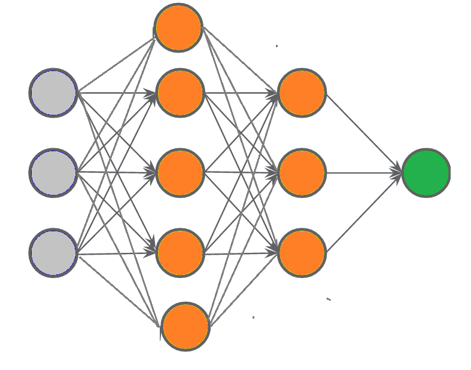

# Details:

## Neuron

Neuron: the basic unit of a neural network. A neuron takes inputs, does some math with them, and produces one output.

The weighted sum of inputs in a neuron can be expressed as: $$ z = \sum_{i=1}^{n} (w_i \cdot x_i) $$

where

$w_i$ is the weight associated with the i-th input.

$x_i$ is the value of the i-th input.

The weighted sum of inputs $z$ in a neuron is then passed through an activation function to produce the neuron's output:

output: $$ y = f(z) $$

Three main types of layers in a neural network:

Input Layer: This layer receives the initial data and passes it on to the next layer. The number of neurons in this layer corresponds to the number of input features or variables.

Hidden Layers: These layers, as the name suggests, are hidden between the input and output layers. They perform complex transformations on the input data through weighted connections and activation functions. The number of hidden layers and neurons in each layer can vary depending on the complexity of the problem.

Output Layer: This layer produces the final results or predictions based on the processed information from the hidden layers. The number of neurons in the output layer depends on the nature of the task. For example, in binary classification, there may be one neuron for each class, while in regression, there's typically a single neuron.

## Hidden Layers and Activation Functions

### 1. Hidden Layers

**Hidden layers**, positioned between the input and output layers, are responsible for capturing the complex relationships within data. Each hidden layer transforms its inputs through weighted connections and nonlinear activation functions, allowing the network to model intricate and high-dimensional patterns that linear models cannot represent.

Without hidden layers or nonlinear activation functions, a neural network behaves like a simple linear model, unable to capture nonlinear dependencies between input and output variables.

The number of hidden layers and neurons in each layer determines the **capacity** and **depth** of the network. Networks with multiple hidden layers are referred to as **deep neural networks (DNNs)**.

### 2. Activation Functions

**Activation functions** introduce **nonlinearity** into the network, enabling neurons to make complex decisions. They determine whether a neuron should be activated, i.e., whether the information it processes is relevant for the given task.  
Without nonlinear activation, stacking multiple layers would still result in a linear transformation.

Below are several commonly used activation functions:

#### (a) Rectified Linear Unit (ReLU)

The **Rectified Linear Unit (ReLU)** is the most widely used activation function in modern deep learning models.

$$ f(x) = \max(0, x) $$

ReLU is computationally efficient and helps mitigate the vanishing gradient problem, enabling deep networks to learn faster and achieve superior performance.  
It is the default activation function for most multilayer perceptrons and convolutional neural networks.

#### (b) Binary Step Function

$$ f(x) = \begin{cases} 0, & x \le 0 \\ 1, & x > 0 \end{cases} $$

This function activates a neuron only if the input exceeds a certain threshold.  
Although conceptually simple, it is rarely used in modern networks because it is not differentiable and cannot be optimized using gradient-based methods.

#### (c) Sigmoid (Logistic) Function

$$ f(x) = \frac{1}{1 + e^{-x}} $$

The **sigmoid** function compresses the input into the range (0,1), making it suitable for binary classification problems.  
However, it can cause vanishing gradients in deep networks, slowing down learning.

#### (d) Hyperbolic Tangent (Tanh) Function

$$ f(x) = \frac{e^{x} - e^{-x}}{e^{x} + e^{-x}} $$

The **tanh** function outputs values in the range (-1, 1) and is often preferred over sigmoid for hidden layers because its mean output is closer to zero, facilitating faster convergence during training.

#### (e) Softmax Function

$$ f(x)_i = \frac{e^{x_i}}{\sum_{j} e^{x_j}} $$

The **softmax** function is primarily used in the **output layer** for multi-class classification.  
It converts a vector of arbitrary real-valued scores into a probability distribution across multiple classes.

### 3. Choosing the Number of Hidden Layers and Neurons

Designing an effective neural network architecture requires balancing model complexity and computational efficiency.  
The following guidelines can serve as a starting point:

- **No hidden layers**: sufficient when data are linearly separable.
- **1–2 hidden layers**: suitable for moderately complex problems with a small number of features.
- **3–5 hidden layers**: effective for complex data with many features or nonlinear relationships.
- **More than 5 layers**: may lead to overfitting or excessive computation unless managed with regularization and large datasets.

**Choosing the number of neurons per layer:**

- Typically between the number of neurons in the input and output layers.
- A common heuristic:
  $$ n_{\text{hidden}} \approx \sqrt{n_{\text{input}} \times n_{\text{output}}} $$
- In deeper networks, later layers often use fewer neurons to extract higher-level abstract features and reduce dimensionality.

These are only general rules; optimal architecture choices should be guided by **experimentation**, **cross-validation**, and the **specific characteristics of the data**.

### Training a neural network

Training a neural network involves optimizing its internal parameters (weights and biases) to minimize a **loss function**, which measures the difference between predicted and actual values.

The process typically involves the following steps:

1. **Forward Propagation** – The input data are passed through the network layer by layer to compute predictions.
2. **Loss Computation** – The network’s predictions are compared to the true target values using a loss function (e.g., mean squared error for regression, cross-entropy for classification).
3. **Backpropagation** – Gradients of the loss with respect to each parameter are computed by applying the **chain rule** in reverse order through the network.
4. **Parameter Update** – Using an optimization algorithm such as **Stochastic Gradient Descent (SGD)** or its variants (e.g., Adam, RMSProp), the parameters are updated iteratively to reduce the loss.

A typical update step for SGD is given by:

$$ w_{ij}^{(t+1)} = w_{ij}^{(t)} - \eta \frac{\partial L}{\partial w_{ij}} $$

where

- $w_{ij}$: weight connecting neuron $i$ to neuron $j$,
- $\eta$: learning rate, and
- $\frac{\partial L}{\partial w_{ij}}$: gradient of the loss function with respect to that weight.

Through repeated iterations, the network gradually adjusts its parameters to minimize the loss, improving its accuracy and generalization to unseen data.

Learning rate ($\eta$) = How aggressively we learn from the data. A small $\eta$ → slow convergence, might get stuck in local minima. A large $\eta$ → unstable training or divergence (loss oscillates or explodes). Regularization strength ($\lambda$) = How cautious we are about overfitting. Together, they balance learning dynamics (speed) and model generalization (stability).

**Feature scaling** is one of the most critical preprocessing steps when training a neural network. It ensures that each feature contributes equally to the model’s learning process and helps the optimization algorithm (such as gradient descent) converge faster and more reliably.

**Min–Max Normalization**

For a feature value $x$:

$$ x' = \frac{x - \min(x)}{\max(x) - \min(x)} $$

where

- $x'$: normalized value (typically in [0, 1])
- $\min(x)$: minimum value of the feature
- $\max(x)$: maximum value of the feature

**Inverse Min–Max Transformation**

To recover the original value $x$ from the normalized value $x'$:

$$ x = x' \times (\max(x) - \min(x)) + \min(x) $$

Example. Using the Boston dataset from the MASS package, build a neural network to predict medv from all other predictors.

For tasks of this scale, neuralnet or nnet is often sufficient. For more complex problems or deep learning applications, frameworks such as Keras or TensorFlow (CPU/GPU) provide greater flexibility and advanced features. If you want to boost predictive performance via ensembling, consider models like avNNet or related ensemble methods.

The neuralnet package is widely used for simple feed-forward neural networks (multilayer perceptrons). The nnet package builds simple, single-hidden-layer feed-forward neural networks that are fast and efficient for basic regression or classification tasks. In contrast, neuralnet supports multiple hidden layers, offers more flexibility, and provides detailed visualization of the network structure and training process.

a. Use the neuralnet package to build a neural network model that predicts medv using all other features on a training dataset. For more information about the neuralnet package, refer to its documentation on Training of Neural Networks (?neuralnet).

b. Use the nnet package to build a neural network model that predicts medv using all other features on a training dataset. Evaluate the model’s performance on a testing dataset using appropriate metrics such as RMSE or $R^2$.

c. Use the average nnet (ensemble models) to build a predictive model that predicts medv using all other features on a training dataset. Evaluate the model’s performance on a testing dataset using appropriate metrics such as RMSE or $R^2$.

Without scaling, variables measured on larger numerical ranges can dominate those on smaller ranges, leading to biased weight updates and slower or unstable learning. For instance, a feature measured in thousands (e.g., “income”) could overshadow a small-range feature like “age” or “BMI”.

```r
# Use the boston housing data
# Build a neural net model to predict "medv" using all other features
library(MASS)
library(neuralnet)
library(tidyverse)
library(caret)
#Method = "nnet"
library(nnet)
```

```r
data(Boston)
str(Boston)

#There are 14 varables:  medv is the price of house (response)
```

```
'data.frame':	506 obs. of  14 variables:
 $ crim   : num  0.00632 0.02731 0.02729 0.03237 0.06905 ...
 $ zn     : num  18 0 0 0 0 0 12.5 12.5 12.5 12.5 ...
 $ indus  : num  2.31 7.07 7.07 2.18 2.18 2.18 7.87 7.87 7.87 7.87 ...
 $ chas   : int  0 0 0 0 0 0 0 0 0 0 ...
 $ nox    : num  0.538 0.469 0.469 0.458 0.458 0.458 0.524 0.524 0.524 0.524 ...
 $ rm     : num  6.58 6.42 7.18 7 7.15 ...
 $ age    : num  65.2 78.9 61.1 45.8 54.2 58.7 66.6 96.1 100 85.9 ...
 $ dis    : num  4.09 4.97 4.97 6.06 6.06 ...
 $ rad    : int  1 2 2 3 3 3 5 5 5 5 ...
 $ tax    : num  296 242 242 222 222 222 311 311 311 311 ...
 $ ptratio: num  15.3 17.8 17.8 18.7 18.7 18.7 15.2 15.2 15.2 15.2 ...
 $ black  : num  397 397 393 395 397 ...
 $ lstat  : num  4.98 9.14 4.03 2.94 5.33 ...
 $ medv   : num  24 21.6 34.7 33.4 36.2 28.7 22.9 27.1 16.5 18.9 ...
```

```r
set.seed(252)

#Data preprcessing
#scaling   - way 1
##min-max normalization
#min-max normalization
#Min–Max Normalization (also called rescaling) is a data preprocessing technique that transforms features to a fixed range, typically [0, 1] or sometimes [-1, 1].
#It ensures that all variables contribute equally to the model and prevents features with larger numerical ranges from dominating the learning process.
scale.fun = function(x){
  (x - min(x)) / (max(x) - min(x))
}

miny = min(Boston$medv)
range.y =  max(Boston$medv) - miny

# Standardization (Z-score scaling)
#X_scaled = scale(X_train)

# Min-Max normalization (manual)
#X_minmax = as.data.frame(  lapply(X_train, function(x) (x - min(x)) / (max(x) - min(x))) )
#preProc = preProcess(data, method = "range")  # scales to [0,1]
#data_norm = predict(preProc, data)

#Transformed data after min_max scaling
Boston.dat = Boston %>%  mutate_all(scale.fun)
head(Boston.dat)
```

A data.frame: 6 × 14

|  | crim <dbl> | zn <dbl> | indus <dbl> | chas <dbl> | nox <dbl> | rm <dbl> | age <dbl> | dis <dbl> | rad <dbl> | tax <dbl> | ptratio <dbl> | black <dbl> | lstat <dbl> | medv <dbl> |
| --- | --- | --- | --- | --- | --- | --- | --- | --- | --- | --- | --- | --- | --- | --- |
| 1 | 0.0000000000 | 0.18 | 0.06781525 | 0 | 0.3148148 | 0.5775053 | 0.6416066 | 0.2692031 | 0.00000000 | 0.20801527 | 0.2872340 | 1.0000000 | 0.08967991 | 0.4222222 |
| 2 | 0.0002359225 | 0.00 | 0.24230205 | 0 | 0.1728395 | 0.5479977 | 0.7826982 | 0.3489620 | 0.04347826 | 0.10496183 | 0.5531915 | 1.0000000 | 0.20447020 | 0.3688889 |
| 3 | 0.0002356977 | 0.00 | 0.24230205 | 0 | 0.1728395 | 0.6943859 | 0.5993821 | 0.3489620 | 0.04347826 | 0.10496183 | 0.5531915 | 0.9897373 | 0.06346578 | 0.6600000 |
| 4 | 0.0002927957 | 0.00 | 0.06304985 | 0 | 0.1502058 | 0.6585553 | 0.4418126 | 0.4485446 | 0.08695652 | 0.06679389 | 0.6489362 | 0.9942761 | 0.03338852 | 0.6311111 |
| 5 | 0.0007050701 | 0.00 | 0.06304985 | 0 | 0.1502058 | 0.6871048 | 0.5283213 | 0.4485446 | 0.08695652 | 0.06679389 | 0.6489362 | 1.0000000 | 0.09933775 | 0.6933333 |
| 6 | 0.0002644715 | 0.00 | 0.06304985 | 0 | 0.1502058 | 0.5497222 | 0.5746653 | 0.4485446 | 0.08695652 | 0.06679389 | 0.6489362 | 0.9929901 | 0.09602649 | 0.5266667 |

```r
#Split the data
#Split the data into training and testing set according to medv

index = createDataPartition(Boston$medv, p = 0.8, list = FALSE)
train.dat = Boston.dat[index,]
test.dat =   Boston.dat[-index,]
```

```r
#Build a neural network on the training data
#hidden = c(6, 4) : two hidder layers,  6 neurons in the first hidden layer and 4 neurons in the second hidder layer
nn.fit = neuralnet(medv ~ ., data = train.dat, hidden = c(6, 4), linear.output = 1)
```

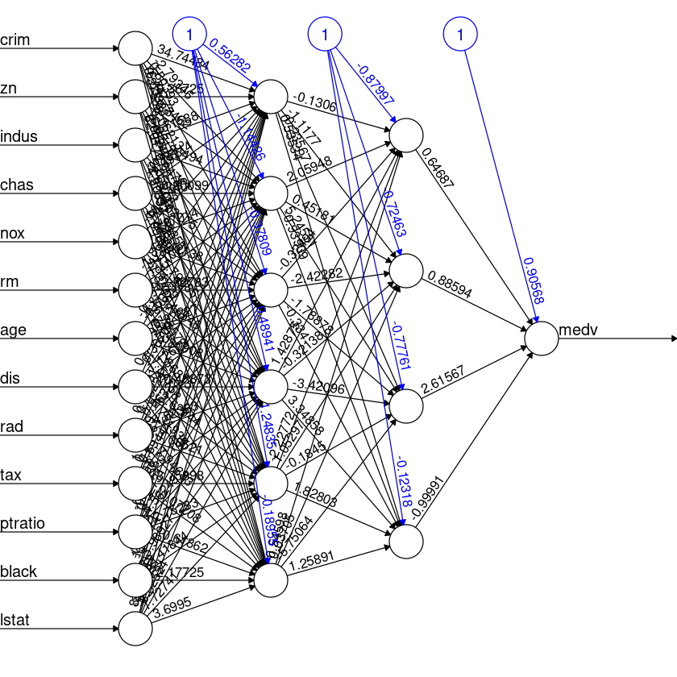

```r
plot(nn.fit, rep = "best")
#The number of weights :  a lot

#library(NeuralNetTools)
#plotnet(nn.fit)
```